# Exercise2-STA6543

Richard Rodriguez-ccb680

6/25/2021

Chapter 03 (page 120): 2, 9, 10, 12

2.) Carefully explain the differences between the KNN classifier and KNN regression methods.

2.) Answer KNN classifier assigns classification group based on majority of closest observations while the KNN regression averages the closest observations to an estimated prediction.

9.) This question involves the use of multiple linear regression on the Auto data set.

9a.) Produce a scatterplot matrix which includes all of the variables in the Auto data set.

[output not shown]

[output cut: 382 more lines]

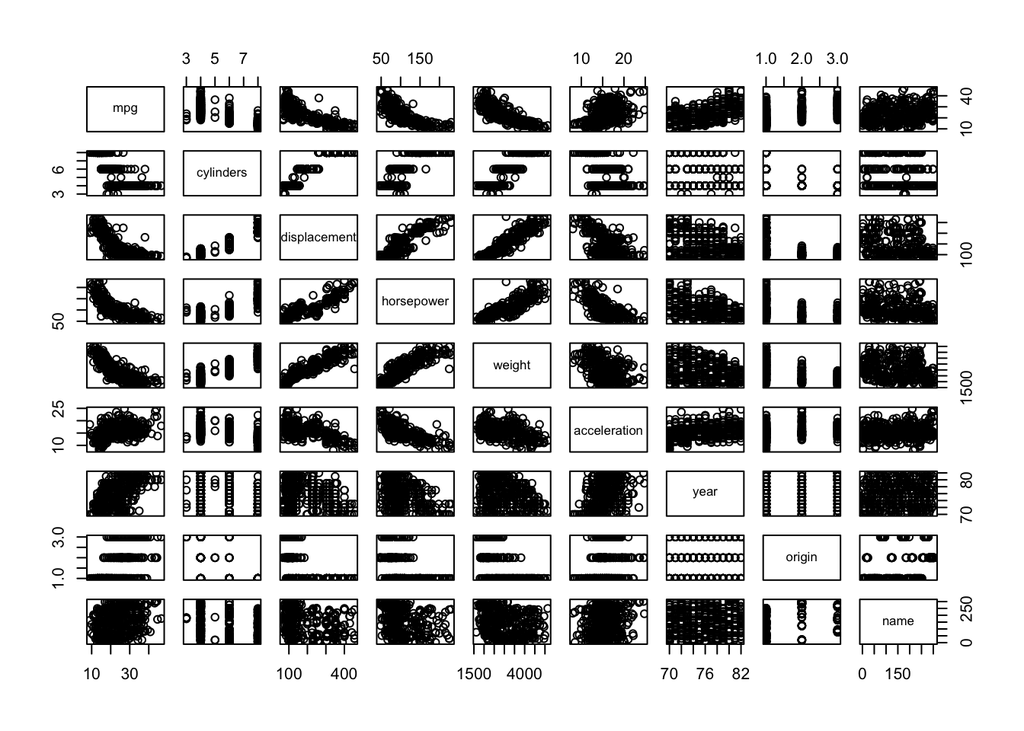

9b. Compute the matrix of correlations between the variables using the function cor(). You will need to exclude the name variable, which is qualitative.

```r
                cor(subset(auto_alt, select=-name))
```

```
                ##                     mpg  cylinders displacement horsepower     weight
                ## mpg           1.0000000 -0.7776175   -0.8051269 -0.7784268 -0.8322442
                ## cylinders    -0.7776175  1.0000000    0.9508233  0.8429834  0.8975273
                ## displacement -0.8051269  0.9508233    1.0000000  0.8972570  0.9329944
                ## horsepower   -0.7784268  0.8429834    0.8972570  1.0000000  0.8645377
                ## weight       -0.8322442  0.8975273    0.9329944  0.8645377  1.0000000
                ## acceleration  0.4233285 -0.5046834   -0.5438005 -0.6891955 -0.4168392
                ## year          0.5805410 -0.3456474   -0.3698552 -0.4163615 -0.3091199
                ## origin        0.5652088 -0.5689316   -0.6145351 -0.4551715 -0.5850054
                ##              acceleration       year     origin
                ## mpg             0.4233285  0.5805410  0.5652088
                ## cylinders      -0.5046834 -0.3456474 -0.5689316
                ## displacement   -0.5438005 -0.3698552 -0.6145351
                ## horsepower     -0.6891955 -0.4163615 -0.4551715
                ## weight         -0.4168392 -0.3091199 -0.5850054
                ## acceleration    1.0000000  0.2903161  0.2127458
                ## year            0.2903161  1.0000000  0.1815277
                ## origin          0.2127458  0.1815277  1.0000000
```

```r
                fit.lm <- lm(mpg~.-name, data=auto_alt)
                summary(fit.lm)
```

```
                ##
                ## Call:
                ## lm(formula = mpg ~ . - name, data = auto_alt)
                ##
                ## Residuals:
                ##     Min      1Q  Median      3Q     Max
                ## -9.5903 -2.1565 -0.1169  1.8690 13.0604
                ##
                ## Coefficients:
                ##                Estimate Std. Error t value Pr(>|t|)
                ## (Intercept)  -17.218435   4.644294  -3.707  0.00024 ***
                ## cylinders     -0.493376   0.323282  -1.526  0.12780
                ## displacement   0.019896   0.007515   2.647  0.00844 **
                ## horsepower    -0.016951   0.013787  -1.230  0.21963
                ## weight        -0.006474   0.000652  -9.929  < 2e-16 ***
                ## acceleration   0.080576   0.098845   0.815  0.41548
                ## year           0.750773   0.050973  14.729  < 2e-16 ***
                ## origin         1.426141   0.278136   5.127 4.67e-07 ***
                ## ---
                ## Signif. codes:  0 '***' 0.001 '**' 0.01 '*' 0.05 '.' 0.1 ' ' 1
                ##
                ## Residual standard error: 3.328 on 384 degrees of freedom
                ## Multiple R-squared:  0.8215, Adjusted R-squared:  0.8182
                ## F-statistic: 252.4 on 7 and 384 DF,  p-value: < 2.2e-16
```

9c.i) Is there a relationship between the predictors and the response? Answer: Yes, there is a relationship between predictors and response

9c.ii) Which predictors appear to have a statistically significant relationship to the response? Answer: `weight` , `year` , `origin` and `displacement` have statistically significant relationships.

9c.iii) What does the coefficient for the year variable suggest? Answer: 0.75 coefficient for `year` suggests that later model year cars have better (higher) `mpg`

9d.) Use the plot() function to produce diagnostic plots of the linear regression fit. Comment on any problems you see with the fit.

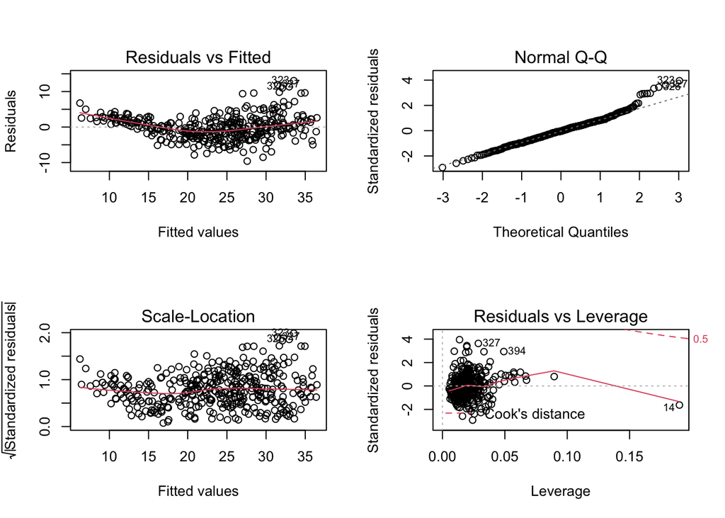

```r
                par(mfrow=c(2,2))

                plot(fit.lm)
```

9d. Do the residual plots suggest any unusually large outliers? Yes. Does the leverage plot identify any observations with unusually high leverage? On the Residuals vs. leverage plot, observation 14 has a high leverage.

9e. Use the * and : symbols to fit linear regression models with interaction effects. Do any interactions appear to be statistically significant?

```r
                fit.lm0 <- lm(mpg~displacement+weight+year+origin, data=auto_alt)

                fit.lm1 <- lm(mpg~displacement+weight+year*origin, data=auto_alt)

                fit.lm2 <- lm(mpg~displacement+origin+year*weight, data=auto_alt)

                fit.lm3 <- lm(mpg~year+origin+displacement*weight, data=auto_alt)

                summary(fit.lm0)
```

```
                ##
                ## Call:
                ## lm(formula = mpg ~ displacement + weight + year + origin, data = auto_alt)
                ##
                ## Residuals:
                ##     Min      1Q  Median      3Q     Max
                ## -9.8102 -2.1129 -0.0388  1.7725 13.2085
                ##
                ## Coefficients:
                ##                Estimate Std. Error t value Pr(>|t|)
                ## (Intercept)  -1.861e+01  4.028e+00  -4.620 5.25e-06 ***
                ## displacement  5.588e-03  4.768e-03   1.172    0.242
                ## weight       -6.575e-03  5.571e-04 -11.802  < 2e-16 ***
                ## year          7.714e-01  4.981e-02  15.486  < 2e-16 ***
                ## origin        1.226e+00  2.670e-01   4.593 5.92e-06 ***
                ## ---
                ## Signif. codes:  0 '***' 0.001 '**' 0.01 '*' 0.05 '.' 0.1 ' ' 1
                ##
                ## Residual standard error: 3.346 on 387 degrees of freedom
                ## Multiple R-squared:  0.8181, Adjusted R-squared:  0.8162
                ## F-statistic: 435.1 on 4 and 387 DF,  p-value: < 2.2e-16
```

```r
                summary(fit.lm1)
```

```
                ##
                ## Call:
                ## lm(formula = mpg ~ displacement + weight + year * origin, data = auto_alt)
                ##
                ## Residuals:
                ##     Min      1Q  Median      3Q     Max
                ## -8.7541 -1.8722 -0.0936  1.6900 12.4650
                ##
                ## Coefficients:
                ##                Estimate Std. Error t value Pr(>|t|)
                ## (Intercept)   7.927e+00  8.873e+00   0.893 0.372229
                ## displacement  1.551e-03  4.859e-03   0.319 0.749735
                ## weight       -6.394e-03  5.526e-04 -11.571  < 2e-16 ***
                ## year          4.313e-01  1.130e-01   3.818 0.000157 ***
                ## origin       -1.449e+01  4.707e+00  -3.079 0.002225 **
                ## year:origin   2.023e-01  6.047e-02   3.345 0.000904 ***
                ## ---
                ## Signif. codes:  0 '***' 0.001 '**' 0.01 '*' 0.05 '.' 0.1 ' ' 1
                ##
                ## Residual standard error: 3.303 on 386 degrees of freedom
                ## Multiple R-squared:  0.8232, Adjusted R-squared:  0.8209
                ## F-statistic: 359.5 on 5 and 386 DF,  p-value: < 2.2e-16
```

```r
                summary(fit.lm2)
```

```
                ##
                ## Call:
                ## lm(formula = mpg ~ displacement + origin + year * weight, data = auto_alt)
                ##
                ## Residuals:
                ##     Min      1Q  Median      3Q     Max
                ## -8.9402 -1.8736 -0.0966  1.5924 12.2125
                ##
                ## Coefficients:
                ##                Estimate Std. Error t value Pr(>|t|)
                ## (Intercept)  -1.076e+02  1.290e+01  -8.339 1.34e-15 ***
                ## displacement -4.020e-04  4.558e-03  -0.088 0.929767
                ## origin        9.116e-01  2.547e-01   3.579 0.000388 ***
                ## year          1.962e+00  1.716e-01  11.436  < 2e-16 ***
                ## weight        2.605e-02  4.552e-03   5.722 2.12e-08 ***
                ## year:weight  -4.305e-04  5.967e-05  -7.214 2.89e-12 ***
                ## ---
                ## Signif. codes:  0 '***' 0.001 '**' 0.01 '*' 0.05 '.' 0.1 ' ' 1
                ##
                ## Residual standard error: 3.145 on 386 degrees of freedom
                ## Multiple R-squared:  0.8397, Adjusted R-squared:  0.8376
                ## F-statistic: 404.4 on 5 and 386 DF,  p-value: < 2.2e-16
```

```r
                summary(fit.lm3)
```

```
                ##
                ## Call:
                ## lm(formula = mpg ~ year + origin + displacement * weight, data = auto_alt)
                ##
                ## Residuals:
                ##      Min       1Q   Median       3Q      Max
                ## -10.6119  -1.7290  -0.0115   1.5609  12.5584
                ##
                ## Coefficients:
                ##                       Estimate Std. Error t value Pr(>|t|)
                ## (Intercept)         -8.007e+00  3.798e+00  -2.108   0.0357 *
                ## year                 8.194e-01  4.518e-02  18.136  < 2e-16 ***
                ## origin               3.567e-01  2.574e-01   1.386   0.1666
                ## displacement        -7.148e-02  9.176e-03  -7.790 6.27e-14 ***
                ## weight              -1.054e-02  6.530e-04 -16.146  < 2e-16 ***
                ## displacement:weight  2.104e-05  2.214e-06   9.506  < 2e-16 ***
                ## ---
                ## Signif. codes:  0 '***' 0.001 '**' 0.01 '*' 0.05 '.' 0.1 ' ' 1
                ##
                ## Residual standard error: 3.016 on 386 degrees of freedom
                ## Multiple R-squared:  0.8526, Adjusted R-squared:  0.8507
                ## F-statistic: 446.5 on 5 and 386 DF,  p-value: < 2.2e-16
```

9e.) Comments All interactions tested seem to have statistically significant effects.

9f. Try a few different transformations of the variables, such as log(X), √X, X2. Comment on your findings.

```r
                fit.lm4 <- lm(mpg~poly(displacement,3)+weight+year+origin, data=auto_alt)

                fit.lm5 <- lm(mpg~displacement+I(log(weight))+year+origin, data=auto_alt)

                fit.lm6 <- lm(mpg~displacement+I(weight^2)+year+origin, data=auto_alt)

                summary(fit.lm4)
```

```
                ##
                ## Call:
                ## lm(formula = mpg ~ poly(displacement, 3) + weight + year + origin,
                ##     data = auto_alt)
                ##
                ## Residuals:
                ##      Min       1Q   Median       3Q      Max
                ## -11.8131  -1.8012   0.0788   1.5566  12.3181
                ##
                ## Coefficients:
                ##                          Estimate Std. Error t value Pr(>|t|)
                ## (Intercept)            -2.342e+01  3.802e+00  -6.160 1.84e-09 ***
                ## poly(displacement, 3)1 -1.701e+01  9.820e+00  -1.732   0.0840 .
                ## poly(displacement, 3)2  2.840e+01  3.610e+00   7.866 3.74e-14 ***
                ## poly(displacement, 3)3 -7.996e+00  3.164e+00  -2.527   0.0119 *
                ## weight                 -5.285e-03  5.419e-04  -9.753  < 2e-16 ***
                ## year                    8.189e-01  4.660e-02  17.572  < 2e-16 ***
                ## origin                  2.422e-01  2.761e-01   0.877   0.3810
                ## ---
                ## Signif. codes:  0 '***' 0.001 '**' 0.01 '*' 0.05 '.' 0.1 ' ' 1
                ##
                ## Residual standard error: 3.102 on 385 degrees of freedom
                ## Multiple R-squared:  0.8445, Adjusted R-squared:  0.842
                ## F-statistic: 348.4 on 6 and 385 DF,  p-value: < 2.2e-16
```

```r
                summary(fit.lm5)
```

```
                ##
                ## Call:
                ## lm(formula = mpg ~ displacement + I(log(weight)) + year + origin,
                ##     data = auto_alt)
                ##
                ## Residuals:
                ##     Min      1Q  Median      3Q     Max
                ## -9.7136 -1.9214  0.0447  1.5790 12.9864
                ##
                ## Coefficients:
                ##                  Estimate Std. Error t value Pr(>|t|)
                ## (Intercept)    131.274483  11.082986  11.845  < 2e-16 ***
                ## displacement     0.007711   0.004052   1.903 0.057810 .
                ## I(log(weight)) -21.584745   1.451851 -14.867  < 2e-16 ***
                ## year             0.804835   0.046532  17.296  < 2e-16 ***
                ## origin           0.836143   0.250485   3.338 0.000925 ***
                ## ---
                ## Signif. codes:  0 '***' 0.001 '**' 0.01 '*' 0.05 '.' 0.1 ' ' 1
                ##
                ## Residual standard error: 3.113 on 387 degrees of freedom
                ## Multiple R-squared:  0.8425, Adjusted R-squared:  0.8409
                ## F-statistic: 517.7 on 4 and 387 DF,  p-value: < 2.2e-16
```

```r
                summary(fit.lm6)
```

```
                ##
                ## Call:
                ## lm(formula = mpg ~ displacement + I(weight^2) + year + origin,
                ##     data = auto_alt)
                ##
                ## Residuals:
                ##      Min       1Q   Median       3Q      Max
                ## -10.0988  -2.2549  -0.1057   1.8704  13.4702
                ##
                ## Coefficients:
                ##                Estimate Std. Error t value Pr(>|t|)
                ## (Intercept)  -2.609e+01  4.349e+00  -5.999 4.56e-09 ***
                ## displacement -9.114e-03  5.118e-03  -1.781   0.0757 .
                ## I(weight^2)  -7.068e-07  9.075e-08  -7.789 6.28e-14 ***
                ## year          7.336e-01  5.380e-02  13.635  < 2e-16 ***
                ## origin        1.488e+00  2.900e-01   5.132 4.56e-07 ***
                ## ---
                ## Signif. codes:  0 '***' 0.001 '**' 0.01 '*' 0.05 '.' 0.1 ' ' 1
                ##
                ## Residual standard error: 3.628 on 387 degrees of freedom
                ## Multiple R-squared:  0.7861, Adjusted R-squared:  0.7839
                ## F-statistic: 355.7 on 4 and 387 DF,  p-value: < 2.2e-16
```

9f. Comments: `displacement` X^2 has a larger effect than other `displacement` polynomials

10. This question should be answered using the Carseats data set.

10a.) Fit a multiple regression model to predict Sales using Price, Urban, and US.

```r
                data(Carseats)

                fit.lm <- lm(Sales ~ Price + Urban + US, data=Carseats)

                summary(fit.lm)
```

```
                ##
                ## Call:
                ## lm(formula = Sales ~ Price + Urban + US, data = Carseats)
                ##
                ## Residuals:
                ##     Min      1Q  Median      3Q     Max
                ## -6.9206 -1.6220 -0.0564  1.5786  7.0581
                ##
                ## Coefficients:
                ##              Estimate Std. Error t value Pr(>|t|)
                ## (Intercept) 13.043469   0.651012  20.036  < 2e-16 ***
                ## Price       -0.054459   0.005242 -10.389  < 2e-16 ***
                ## UrbanYes    -0.021916   0.271650  -0.081    0.936
                ## USYes        1.200573   0.259042   4.635 4.86e-06 ***
                ## ---
                ## Signif. codes:  0 '***' 0.001 '**' 0.01 '*' 0.05 '.' 0.1 ' ' 1
                ##
                ## Residual standard error: 2.472 on 396 degrees of freedom
                ## Multiple R-squared:  0.2393, Adjusted R-squared:  0.2335
                ## F-statistic: 41.52 on 3 and 396 DF,  p-value: < 2.2e-16
```

10b.) Provide an interpretation of each coefficient in the model. Be careful—some of the variables in the model are qualitative!

Sales: sales in thousands at each location Price: price charged for car seats at each location Urban: No/Yes by location US: No/Yes by location

Coefficients for

Price (-0.054459): Sales drop by 54 for each dollar increase in Price and statistically significant UrbanYes (-0.021916): Sales are 22 lower for Urban locations and not statistically significant USYes (1.200573): Sales are 1,201 higher in the US locations and statistically significant

10c.) Write out the model in equation form, being careful to handle the qualitative variables properly.

10c.) Answer: Sales = 13.043 - 0.054 x Price - 0.022 x UrbanYes + 1.201 x USYes

10d.) For which of the predictors can you reject the null hypothesis H0 : βj = 0?

10d.) Answer: Can reject null hypothesis for Price and USYes (coefficients have low p-values)

10e.) On the basis of your response to the previous question, fit a smaller model that only uses the predictors for which there is evidence of association with the outcome.

```r
                fit.lm1 <- lm(Sales ~ Price + US, data=Carseats)

                summary(fit.lm1)
```

```
                ##
                ## Call:
                ## lm(formula = Sales ~ Price + US, data = Carseats)
                ##
                ## Residuals:
                ##     Min      1Q  Median      3Q     Max
                ## -6.9269 -1.6286 -0.0574  1.5766  7.0515
                ##
                ## Coefficients:
                ##             Estimate Std. Error t value Pr(>|t|)
                ## (Intercept) 13.03079    0.63098  20.652  < 2e-16 ***
                ## Price       -0.05448    0.00523 -10.416  < 2e-16 ***
                ## USYes        1.19964    0.25846   4.641 4.71e-06 ***
                ## ---
                ## Signif. codes:  0 '***' 0.001 '**' 0.01 '*' 0.05 '.' 0.1 ' ' 1
                ##
                ## Residual standard error: 2.469 on 397 degrees of freedom
                ## Multiple R-squared:  0.2393, Adjusted R-squared:  0.2354
                ## F-statistic: 62.43 on 2 and 397 DF,  p-value: < 2.2e-16
```

10f.) How well do the models in (a) and (e) fit the data?

10f.) Answer:

1. `fit.lm` (Price, Urban, US): RSE = 2.472 R^2 = 0.2393
2. `fit.lm1` (Price, US): RSE = 2.469 R^2 = 0.2393
3. `fit.lm1` has a slightly better (lower) RSE value and one less predictor variable.

10g.) Using the model from (e), obtain 95% confidence intervals for the coefficient(s).

```r
                confint(fit.lm1)
```

```
                ##                   2.5 %      97.5 %
                ## (Intercept) 11.79032020 14.27126531
                ## Price       -0.06475984 -0.04419543
                ## USYes        0.69151957  1.70776632
```

10h.) Is there evidence of outliers or high leverage observations in the model from (e)?

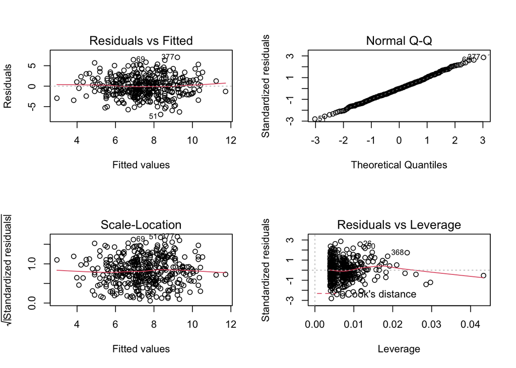

```r
                par(mfrow=c(2,2))
                # Comments: residuals vs fitted plot doesn't show strong outliers

                plot(fit.lm1)
```

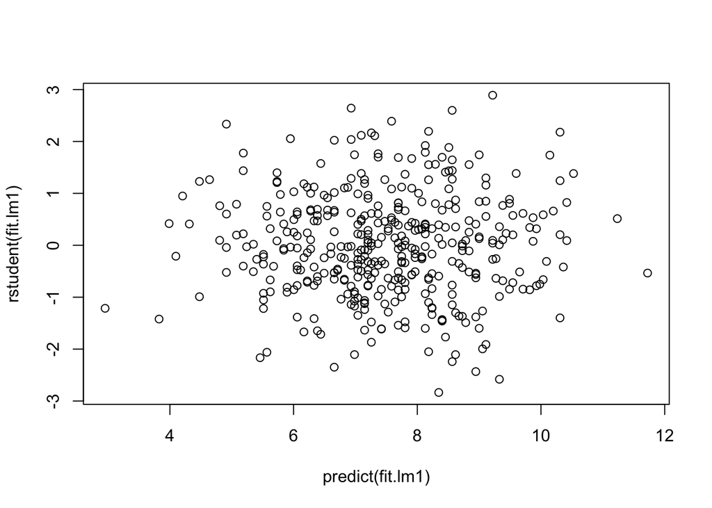

```r
                par(mfrow=c(1,1))
                # studentized residuals within -3 to 3 range

                plot(predict(fit.lm1), rstudent(fit.lm1))
```

```r
                # load car packages

                library (car)
```

```
                ## Loading required package: carData
```

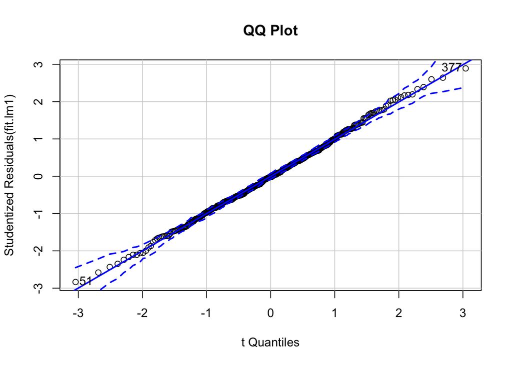

```
                ## [1]  51 377
```

```r
                # no evidence of outliers

                qqPlot(fit.lm1, main="QQ Plot")  # studentized residuals
```

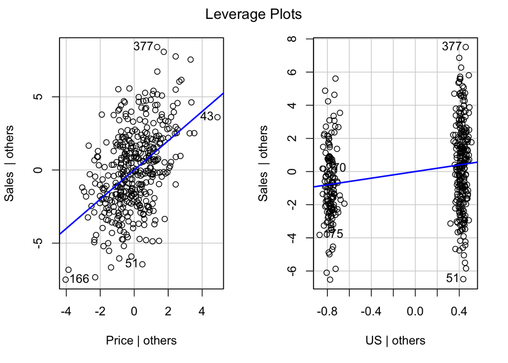

```r
                leveragePlots(fit.lm1)  # leverage plots
```

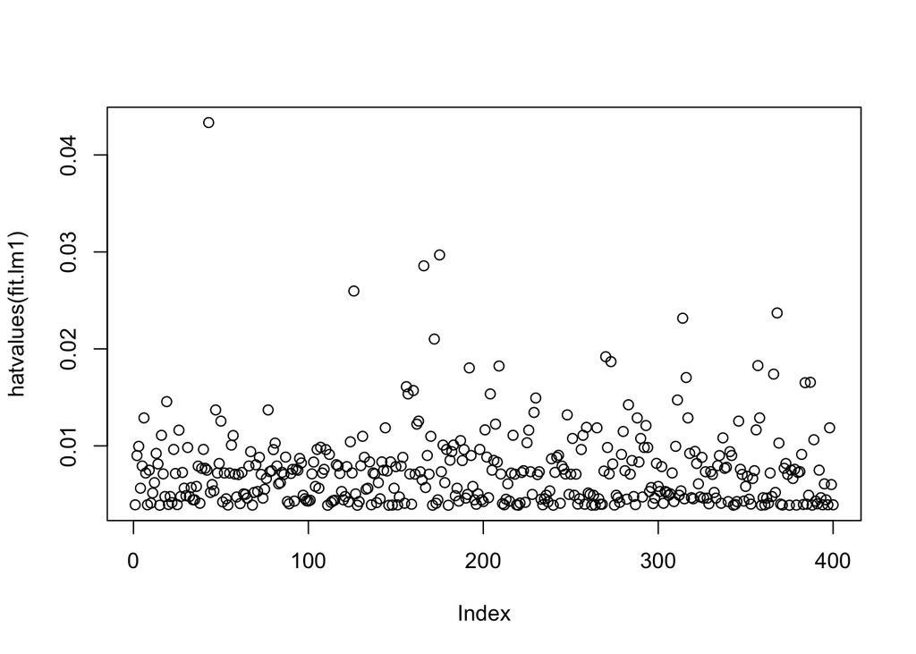

```r
                plot(hatvalues(fit.lm1))
```

```r
                # average obs leverage (p+1)/n = (2+1)/400 = 0.0075
                # data may have some leverage issues
```

12.This problem involves simple linear regression without an intercept.

12a.) Recall that the coefficient estimate (β-hat) for the linear regression of Y onto X without an intercept is given by (3.38). Under what circumstance is the coefficient estimate for the regression of X onto Y the same as the coefficient estimate for the regression of Y onto X?

12a.) Answer: When $x_{i}=y_{i}$ , or more generally when the beta denominators are equal $\sum x_{i}^2=\sum y_{i}^2$

12b.) Generate an example in R with n = 100 observations in which the coefficient estimate for the regression of X onto Y is different from the coefficient estimate for the regression of Y onto X.

```r
                set.seed(1)
                x <- rnorm(100)
                y <- 2*x + rnorm(100)

                fit.lmY <- lm(y ~ x)
                fit.lmX <- lm(x ~ y)

                summary(fit.lmY)
```

```
                ##
                ## Call:
                ## lm(formula = y ~ x)
                ##
                ## Residuals:
                ##     Min      1Q  Median      3Q     Max
                ## -1.8768 -0.6138 -0.1395  0.5394  2.3462
                ##
                ## Coefficients:
                ##             Estimate Std. Error t value Pr(>|t|)
                ## (Intercept) -0.03769    0.09699  -0.389    0.698
                ## x            1.99894    0.10773  18.556   <2e-16 ***
                ## ---
                ## Signif. codes:  0 '***' 0.001 '**' 0.01 '*' 0.05 '.' 0.1 ' ' 1
                ##
                ## Residual standard error: 0.9628 on 98 degrees of freedom
                ## Multiple R-squared:  0.7784, Adjusted R-squared:  0.7762
                ## F-statistic: 344.3 on 1 and 98 DF,  p-value: < 2.2e-16
```

```r
                summary(fit.lmX)
```

```
                ##
                ## Call:
                ## lm(formula = x ~ y)
                ##
                ## Residuals:
                ##      Min       1Q   Median       3Q      Max
                ## -0.90848 -0.28101  0.06274  0.24570  0.85736
                ##
                ## Coefficients:
                ##             Estimate Std. Error t value Pr(>|t|)
                ## (Intercept)  0.03880    0.04266    0.91    0.365
                ## y            0.38942    0.02099   18.56   <2e-16 ***
                ## ---
                ## Signif. codes:  0 '***' 0.001 '**' 0.01 '*' 0.05 '.' 0.1 ' ' 1
                ##
                ## Residual standard error: 0.4249 on 98 degrees of freedom
                ## Multiple R-squared:  0.7784, Adjusted R-squared:  0.7762
                ## F-statistic: 344.3 on 1 and 98 DF,  p-value: < 2.2e-16
```

12b.) Comments: 1.99894 != 0.38942

12c.) Generate an example in R with n = 100 observations in which the coefficient estimate for the regression of X onto Y is the same as the coefficient estimate for the regression of Y onto X.

```r
                set.seed(1)

                x <- rnorm(100, mean=1000, sd=0.1)
                y <- rnorm(100, mean=1000, sd=0.1)

                fit.lmY <- lm(y ~ x)
                fit.lmX <- lm(x ~ y)

                summary(fit.lmY)
```

```
                ##
                ## Call:
                ## lm(formula = y ~ x)
                ##
                ## Residuals:
                ##      Min       1Q   Median       3Q      Max
                ## -0.18768 -0.06138 -0.01395  0.05394  0.23462
                ##
                ## Coefficients:
                ##               Estimate Std. Error t value Pr(>|t|)
                ## (Intercept) 1001.05662  107.72820   9.292 4.16e-15 ***
                ## x             -0.00106    0.10773  -0.010    0.992
                ## ---
                ## Signif. codes:  0 '***' 0.001 '**' 0.01 '*' 0.05 '.' 0.1 ' ' 1
                ##
                ## Residual standard error: 0.09628 on 98 degrees of freedom
                ## Multiple R-squared:  9.887e-07,  Adjusted R-squared:  -0.0102
                ## F-statistic: 9.689e-05 on 1 and 98 DF,  p-value: 0.9922
```

```r
                summary(fit.lmX)
```

```
                ##
                ## Call:
                ## lm(formula = x ~ y)
                ##
                ## Residuals:
                ##       Min        1Q    Median        3Q       Max
                ## -0.232416 -0.060361  0.000536  0.058305  0.229316
                ##
                ## Coefficients:
                ##               Estimate Std. Error t value Pr(>|t|)
                ## (Intercept)  1.001e+03  9.472e+01   10.57   <2e-16 ***
                ## y           -9.324e-04  9.472e-02   -0.01    0.992
                ## ---
                ## Signif. codes:  0 '***' 0.001 '**' 0.01 '*' 0.05 '.' 0.1 ' ' 1
                ##
                ## Residual standard error: 0.09028 on 98 degrees of freedom
                ## Multiple R-squared:  9.887e-07,  Adjusted R-squared:  -0.0102
                ## F-statistic: 9.689e-05 on 1 and 98 DF,  p-value: 0.9922
```